# Nanodegree de Engenheiro de Machine Learning

## Projeto final: Prevendo classificação de músicas sugeridas por usuário do Spotify

Neste projeto, será analisada uma base de dados de um usuário do **Spotify**, contendo diversas informações técnicas sobre as músicas ouvidas e classificadas por ele como "gostei"(1) ou como "não gostei"(0), além do nome da música e artista. Através desses dados, pretende-se implementar um modelo de classificação com **Aprendizado Supervisionado**, onde tal modelo deve ser capaz de classificar corretamente possíveis novas sugestões de músicas para este usuário antes que a sugestão chegue ao mesmo, visando entregar à este cliente tais sugestões de maneira mais assertiva.

A base de dados utilizada neste projeto foi encontrada no repositório de um dos desafios do [Kagle](https://www.kaggle.com/geomack/spotifyclassification/kernels?sortBy=hotness&group=everyone&pageSize=20&datasetId=1833). Essa base de dados possui 17 colunas, incluindo a coluna **id** que possui o index de cada linha, a qual será retirada.

## Implementando um modelo utilizando um classificador SVM

Nesta primeira etapa, utilizaremos o algoritmo *Suport Vector Machine* (SVM) de aprendizado supervisionado para classificar as músicas do usuário em questão. Como o próprio nome já sugere, este algoritmo utiliza vetores de suporte como pontos de referência para efetuar a separação dos dados em classes, através dos quais ele constrói um hiperplano ou um grupo de hiperplanos em um espaço multidimensional. A melhor separação considerada é aquela que possui o(s) hiperplano(s) o mais distante possível dos pontos que estão na fronteira das classes, o que faz com que esse hiperplano represente a maios separação possível, ou maior margem, entre as duas classes.

### Carregando a base de dados

Começaremos, então, carregando a base de dados do **Spotify** como bloco abaixo. Parte do que será feito nesta etapa inicial para escolha dos melhores parâmetros e pré-processamento foi implementada com base no que foi apresentado em um tutorial do site [Minerando Dados](http://minerandodados.com.br/index.php/2018/04/04/spotify-svm-python/), a partir do qual foram feitas diversas alterações para a obtenção de melhores resultados.

```python
import pandas as pd
import numpy as np

dataset = pd.read_csv('data.csv', sep=',')
dataset.rename(index=str, columns={"Unnamed: 0": "id"},  inplace=True)
dataset.shape
```

```
(2017, 17)
```

```python
dataset.head()
```

|  | id | acousticness | danceability | duration_ms | energy | instrumentalness | key | liveness | loudness | mode | speechiness | tempo | time_signature | valence | target | song_title | artist |
| --- | --- | --- | --- | --- | --- | --- | --- | --- | --- | --- | --- | --- | --- | --- | --- | --- | --- |
| 0 | 0 | 0.0102 | 0.833 | 204600 | 0.434 | 0.021900 | 2 | 0.1650 | -8.795 | 1 | 0.4310 | 150.062 | 4.0 | 0.286 | 1 | Mask Off | Future |
| 1 | 1 | 0.1990 | 0.743 | 326933 | 0.359 | 0.006110 | 1 | 0.1370 | -10.401 | 1 | 0.0794 | 160.083 | 4.0 | 0.588 | 1 | Redbone | Childish Gambino |
| 2 | 2 | 0.0344 | 0.838 | 185707 | 0.412 | 0.000234 | 2 | 0.1590 | -7.148 | 1 | 0.2890 | 75.044 | 4.0 | 0.173 | 1 | Xanny Family | Future |
| 3 | 3 | 0.6040 | 0.494 | 199413 | 0.338 | 0.510000 | 5 | 0.0922 | -15.236 | 1 | 0.0261 | 86.468 | 4.0 | 0.230 | 1 | Master Of None | Beach House |
| 4 | 4 | 0.1800 | 0.678 | 392893 | 0.561 | 0.512000 | 5 | 0.4390 | -11.648 | 0 | 0.0694 | 174.004 | 4.0 | 0.904 | 1 | Parallel Lines | Junior Boys |

### Exploração e análise os dados

Nesta etapa, tentou-se observar o comportamento dos dados, analisando-se quais dados necessitariam ser retirados da base de dados, quais precisariam de alguma transformação, além de uma breve analise dos valores apresentados por cara *feature* e o faixa em que se encontram.

```python
dataset.describe()
```

|  | id | acousticness | danceability | duration_ms | energy | instrumentalness | key | liveness | loudness | mode | speechiness | tempo | time_signature | valence | target |
| --- | --- | --- | --- | --- | --- | --- | --- | --- | --- | --- | --- | --- | --- | --- | --- |
| count | 2017.000000 | 2017.000000 | 2017.000000 | 2.017000e+03 | 2017.000000 | 2017.000000 | 2017.000000 | 2017.000000 | 2017.000000 | 2017.000000 | 2017.000000 | 2017.000000 | 2017.000000 | 2017.000000 | 2017.000000 |
| mean | 1008.000000 | 0.187590 | 0.618422 | 2.463062e+05 | 0.681577 | 0.133286 | 5.342588 | 0.190844 | -7.085624 | 0.612295 | 0.092664 | 121.603272 | 3.968270 | 0.496815 | 0.505702 |
| std | 582.402066 | 0.259989 | 0.161029 | 8.198181e+04 | 0.210273 | 0.273162 | 3.648240 | 0.155453 | 3.761684 | 0.487347 | 0.089931 | 26.685604 | 0.255853 | 0.247195 | 0.500091 |
| min | 0.000000 | 0.000003 | 0.122000 | 1.604200e+04 | 0.014800 | 0.000000 | 0.000000 | 0.018800 | -33.097000 | 0.000000 | 0.023100 | 47.859000 | 1.000000 | 0.034800 | 0.000000 |
| 25% | 504.000000 | 0.009630 | 0.514000 | 2.000150e+05 | 0.563000 | 0.000000 | 2.000000 | 0.092300 | -8.394000 | 0.000000 | 0.037500 | 100.189000 | 4.000000 | 0.295000 | 0.000000 |
| 50% | 1008.000000 | 0.063300 | 0.631000 | 2.292610e+05 | 0.715000 | 0.000076 | 6.000000 | 0.127000 | -6.248000 | 1.000000 | 0.054900 | 121.427000 | 4.000000 | 0.492000 | 1.000000 |
| 75% | 1512.000000 | 0.265000 | 0.738000 | 2.703330e+05 | 0.846000 | 0.054000 | 9.000000 | 0.247000 | -4.746000 | 1.000000 | 0.108000 | 137.849000 | 4.000000 | 0.691000 | 1.000000 |
| max | 2016.000000 | 0.995000 | 0.984000 | 1.004627e+06 | 0.998000 | 0.976000 | 11.000000 | 0.969000 | -0.307000 | 1.000000 | 0.816000 | 219.331000 | 5.000000 | 0.992000 | 1.000000 |

**Tamanho e resumo estatístico da base de dados**

Os métodos utilizados acima nos permitem ter informações do tamanho da base de dados, que nesse caso possui 17 colunas e 2017 exemplos de músicas classificadas pelo usuário, além de informações como valores mínimo, máximo e médio de cada coluna.

Falando primeramente da quantidades de dados desta base, podemos considerar uma base não muito grande, mas que aparentemente possui um volume de dados suficiente para gerar um modelo satisfatório. Já falando sobre o resumo estatísticos dos dados (que é aplicado apenas aos dados numéricos da base), podemos observar, por exemplo, que para a *feature* *speechiness* o valor máximo da coluna está bem distante do valor médio, o que pode indicar um *outlier*.

```python
list(dataset.keys())
```

```
['id',
 'acousticness',
 'danceability',
 'duration_ms',
 'energy',
 'instrumentalness',
 'key',
 'liveness',
 'loudness',
 'mode',
 'speechiness',
 'tempo',
 'time_signature',
 'valence',
 'target',
 'song_title',
 'artist']
```

**Descrição das *features***

Podemos observar acima que a base de dados em questão possui 17 features no total, onde não analisaremos a coluna **id**, uma vez que esta indica apenas os índices das colunas. Descrevendo, então, as features desta tabela, temos:

- *acousticness*: **[float]** É uma medida de confiança de 0.0 a 1.0 do quão acústica é a música. 1.0 representa alta confiança de que a música é acústica;
- *danceability*: **[float]** Esta *feature* descreve o quão adequada uma música é para dançar, baseada em uma combinação de elementos musicais incluindo tempo, estabilidade de ritmo, intensidade da batida e regularidade geral. Um valor de 0.0 indica uma música "menos adequada para dançar" e 1.0 "mais adequada para dançar";
- *duration_ms*: **[int]** Indica a duração da música em milissegundos;
- *energy*: **[float]** É uma medição de 0.0 a 1.0 e representa um percentual de intensidade e atividade. Tipicamente, músicas enérgicas parecem mais rápidas, com volume mais alto e barulhentas. Por exemplo, death metal tem alta energia, enquanto que o prelúdio de Bach tem pontuação baixa na escala. Os percentuais de features que contribuem para este atributo incluem faixa dinâmica, volume percebido, timbre, faixa *onset* e entropia geral;
- *instrumentalness*: **[float]** Prevê quando uma música não possui vocais. Sons como "Ooh" e "aah" são considerados instrumentais neste contexto. Rap ou músicas com palavras de fato pronunciadas são claramente um "vocal". Quanto mais próximo de 1.0 mais provável será da música não possuir "vocais". valores acima de 0.5 pretendem representar músicas instrumentais, mas a confiança aumenta à medida que este valor se aproxima de 1.0;
- *key*: **[int]** A chave onde se encontra a música. Mapeamos para inteiros as "alturas" das notas usando o *Pitch Class notaiton* padrão. Ex.: 0 = C, 1 = C#/Db, 2 = D, e assim por diante;
- *liveness*: **[float]** Detecta a presença de uma audiência na gravação. Maior valor de vivacidade representa uma probabilidade alta de que a música foi performada ao vivo. Um valor acima de 0.8 fornece uma forte probabilidade de que que a música é ao vivo;
- *loudness*: **[float]** O volume geral da faixa em decibéis (dB). Valores de volume são calculados ao longo de toda a faixa e são úteis para comparar valores relativos de volume de faixas. Essa variável indica a qualidade da música que é a correlação psicológica primária da força física (amplitude). Tais valores variam entre -60 e 0 db;
- *mode*: **[int]** Esta *feature* indica a modalidade (maior ou menos) de uma faixa, o tipo de escala a partir da qual seu conteúdo melódico é derivado. Maior é representado por 1 e menor por 0;
- *speechiness*: **[float]** Resumidamente, esta variável detecta a presença de palavras faladas em uma música. Quanto mais palavras, mais próximo de um será esse valor. Valores acima de 66% descrevem faixas que são provavelmente feitas inteiramente de palavras ditas. Entre 0.33 e 0.66 descrevem faixas que podem ter ambas música e falsa, e valores abaixo de 0.33 são mais prováveis de serem música ou outra faixa sem falas;
- *tempo*: **[float]** O ritmo global estimado de uma baixa em batidas por minuto (BPM). Na terminologia musical, o ritmo é a velocidade de uma determinada parte e deriva diretamente da média de duração da batida;
- *time_signature*: **[int]** Um tempo de assinatura global estimado de uma faixa. A assinatura de tempo é uma convenção de notação para especificar quantas batidas estão em cada barra (ou medida);
- *valence*: **[float]** Uma medida de 0.0 a 1.0 que descreve a positividade musical transmitida por uma faixa. Faixas com alta valência soam mais positivas, enquanto faixas com valores mais baixos soam mais negativas;
- *target*: **[int]** É a variável de interesse da base de dados, a qual contém a informação de se o usuário gostou (1) ou não (0) das músicas;
- *song_title*: **[string]** Nesta coluna temos o nome de cada música;
- *artist*: **[string]** Esta variável possui a informação do artista da música;

> **Nota:** Todas as descrições acima foram retiradas do próprio site do [*Spotify*](https://beta.developer.spotify.com/documentation/web-api/reference/tracks/get-audio-features/), e foram traduzidas livremente.

```python
%matplotlib notebook

dataset['target'].value_counts()
```

```
1    1020
0     997
Name: target, dtype: int64
```

A coluna *target* nos mostra como este usuário classificou essas músicas, nos informando quais músicas este gostou (1) e quais não gostou (0). Nessa base de dados, como podemos ver logo acima, temos que 1020 músicas foram classificadas como **gosto**(1) e 997 como **não gosto**(0), o que nos indica que as classes estão balanceadas, ou seja, em equilíbrio.

```python
#Checando a existência de dados fantaltes
dataset.isnull().sum()
```

```
id                  0
acousticness        0
danceability        0
duration_ms         0
energy              0
instrumentalness    0
key                 0
liveness            0
loudness            0
mode                0
speechiness         0
tempo               0
time_signature      0
valence             0
target              0
song_title          0
artist              0
dtype: int64
```

**Análise de valores faltantes**

### Visualização dos dados

Como temos muitas dimensões (features) e pontos (músicas) neste espaço multidimensional, fizemos uma reunião de dimensão utilizando PCA e plotamos o resultado como segue.

Os dois código abaixo foram implementados usando um artigo do [Medium](https://medium.com/@luckylwk/visualising-high-dimensional-datasets-using-pca-and-t-sne-in-python-8ef87e7915b) e e uma página com um exemplo da biblioteca [sklearn](http://scikit-learn.org/stable/auto_examples/decomposition/plot_pca_3d.html) que aplicava o PCA à base de dados Iris.

PCA 3D:

```python
#plot do PCA 3D
from sklearn.preprocessing import StandardScaler
from sklearn.decomposition import PCA

#Separando o Target
lable = dataset.target.values
#retirando o target, id e colunas categóricas
dataset_visual = dataset.drop(['target','id','artist','song_title'], axis = 1)
dataset_visual = dataset_visual.values
#Padronizando as features
dataset_visual = StandardScaler().fit_transform(dataset_visual)
```

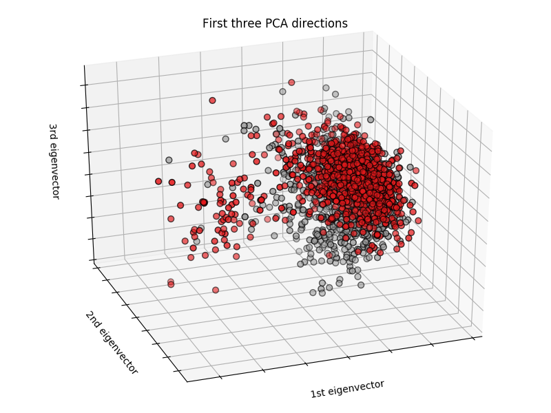

```python
# Code source: Gaël Varoquaux
# Modified for documentation by Jaques Grobler
# License: BSD 3 clause

import matplotlib.pyplot as plt
from mpl_toolkits.mplot3d import Axes3D
from sklearn import datasets
from sklearn.decomposition import PCA

# import some data to play with
X = dataset_visual  # we only take the first two features.
y = dataset.target

x_min, x_max = X[:, 0].min() - .5, X[:, 0].max() + .5
y_min, y_max = X[:, 1].min() - .5, X[:, 1].max() + .5

#plt.figure(2, figsize=(8, 6))
#plt.clf()

##Plot the training points
#plt.scatter(X[:, 0], X[:, 1], c=y, cmap=plt.cm.Set1,
#            edgecolor='k')
#plt.xlabel('PCA1')
#plt.ylabel('PCA2')

#plt.xlim(x_min, x_max)
#plt.ylim(y_min, y_max)
#plt.xticks(())
#plt.yticks(())

# To getter a better understanding of interaction of the dimensions
# plot the first three PCA dimensions
fig3 = plt.figure(2, figsize=(8, 6))
ax2 = Axes3D(fig3, elev=-150, azim=110)

lable = dataset.target.values
#retirando o target, id e colunas categóricas
dataset_visual = dataset.drop(['target','id','artist','song_title'], axis = 1)
dataset_visual = dataset_visual.values
dataset_visual = StandardScaler().fit_transform(dataset_visual)
pca2 = PCA(n_components=3)
principalComponents2  = pca2.fit_transform(dataset_visual)

ax2.scatter(principalComponents2[:, 0], principalComponents2[:, 1], principalComponents2[:, 2], c=lable,
           cmap=plt.cm.Set1, edgecolor='k', s=40)

ax2.set_title("First three PCA directions")
ax2.set_xlabel("1st eigenvector")
ax2.w_xaxis.set_ticklabels([])
ax2.set_ylabel("2nd eigenvector")
ax2.w_yaxis.set_ticklabels([])
ax2.set_zlabel("3rd eigenvector")
ax2.w_zaxis.set_ticklabels([])

plt.show()
```

```python
pca2.explained_variance_ratio_
```

```
array([ 0.21891041,  0.1173393 ,  0.10111497])
```

PCA 2D:

```python
from sklearn.preprocessing import StandardScaler
from sklearn.decomposition import PCA

#Separando o Target
lable = dataset.target.values
#retirando o target, id e colunas categóricas
dataset_visual = dataset.drop(['target','id','artist','song_title'], axis = 1)
dataset_visual = dataset_visual.values
#Padronizando as features
dataset_visual = StandardScaler().fit_transform(dataset_visual)
pca = PCA(n_components = 2)

principalComponents = pca.fit_transform(dataset_visual)
principalDf = pd.DataFrame(data = principalComponents
             , columns = ['principal component 1', 'principal component 2'])
```

```python
principalDf['target'] = dataset.target.values
finalDf = principalDf
```

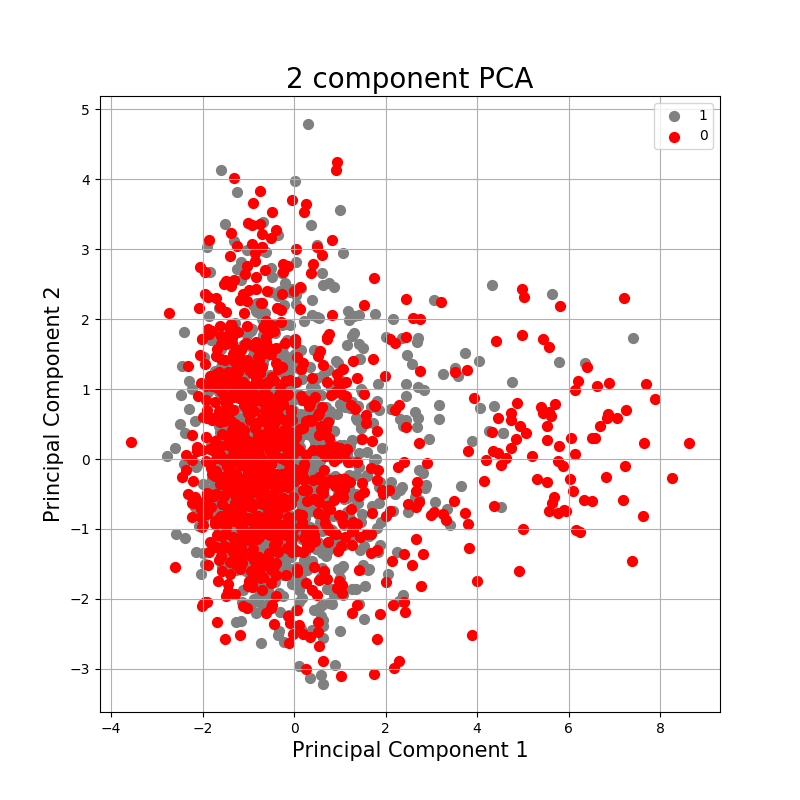

```python
import matplotlib.pyplot as plt
fig1 = plt.figure(1,figsize = (8,8))
ax = fig1.add_subplot(1,1,1)
ax.set_xlabel('Principal Component 1', fontsize = 15)
ax.set_ylabel('Principal Component 2', fontsize = 15)
ax.set_title('2 component PCA', fontsize = 20)
targets = [1, 0]
colors = [ 'gray','r']
for target, color in zip(targets,colors):
    indicesToKeep = finalDf['target'] == target
    ax.scatter(finalDf.loc[indicesToKeep, 'principal component 1']
               , finalDf.loc[indicesToKeep, 'principal component 2']
               , c = color
               , s = 50)
ax.legend(targets)
ax.grid()
```

```python
pca.explained_variance_ratio_
```

```
array([ 0.21891041,  0.1173393 ])
```

**Analisando os gráficos gerados com PCA**

Os dois gráficos gerados com PCA mostram que os dados estão muito misturados e que não existe em nenhum momento uma divisão clara entre as classes. Isso nos leva a crer que todas as features existentes na base são relevantes, fazendo com que a remoção de features não seja interessante para esta base. Outro fator que comprova isso é o resultado baixo da variância de ambos.Além disos, tais gráficos também mostram a existência de possíveis outliers.

Plotando, agora, os pontos de algumas variáveis em relação à outras, podemos ver o grau de dispersão dessas variáveis com relação à classe (*target*). Esse passo objetiva evidenciar possíveis padrões existentes nos dados e features que direcionem consideravelmente as escolhas do usuário.

```python
#configurando o jupyter notebook para exibir os gráficos do MatPlotLib
%matplotlib notebook
from matplotlib import style

style.use('seaborn-colorblind')
```

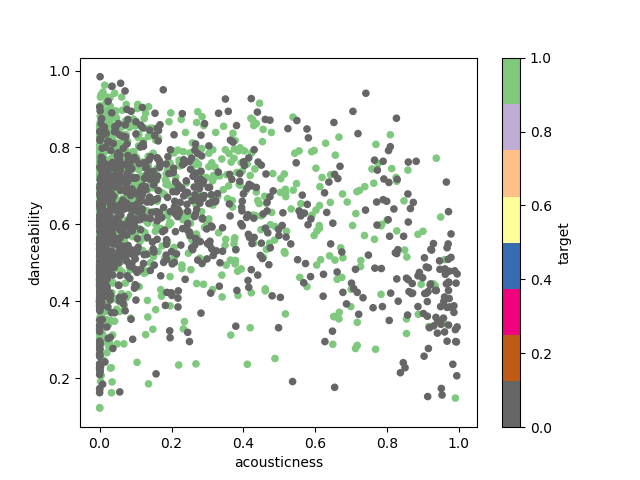

```python
dataset.plot(x='acousticness', y='danceability', c='target', kind='scatter', colormap='Accent_r')
```

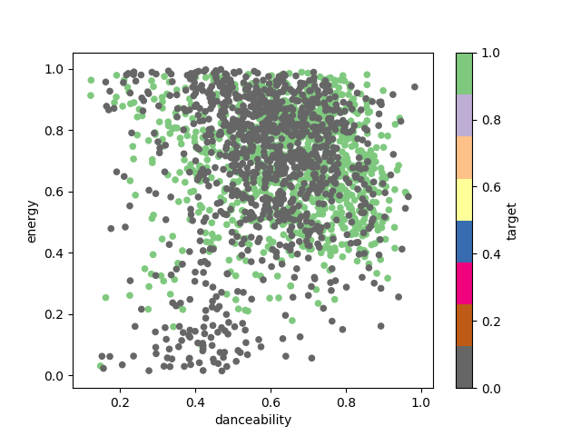

```python
dataset.plot(x='danceability', y='energy', c='target', kind='scatter', colormap='Accent_r')
```

**Análise dos dois gráficos acima**

Ambas as figuras mostradas acima, da mesma forma que nas imagens geradas pelo PCA, que os pontos continuam misturados, ocorrendo apenas, em algumas regiões, a identificação de que aparentemente existem mais músicas classificadas como "gostei" (verde claro), como na figura 2, quando danceability é maior é 0.8 e energy maior que 0.4.

## Pré-processamento com *One Hot Encoder*

Como foi possível observar na sessão 1.2.2, as colunas *artist* e *song_title* são preenchidas com dados do tipo *string*, ou seja, são considerados dados categóricos.

O nome da música, entretanto, não tem tanta relevância para um classificador, já que praticamente todas os nomes são uns diferentes dos outros. Contudo, a feature *artist* deve ser mais relevante pois, se um usuário gosta de algumas músicas de um artista, é possível que goste de mais.

O algoritmo que será implementado nesta etapa trabalha somente com dados numéricos. Dessa forma, será necessário transformar essas informações categóricos contidas em *artist* em valores numéricos. Usaremos então, primeiramente, o *One Hot Encoder*.

Esta técnica converte os valores categóricos em valores binários, dando como resultado uma matriz de presença. Isto é, se temos três artistas: \textit{The Beatles}, \textit{Beyoncé} e \textit{Interpol}, estes se tornarão colunas da base de dados, ou seja, se a linha 1 refere-se à uma música dos \textit{The Beatles}, as células dessas novas features ficarão preenchidas com **1**, **0** e **0**, respectivamente.

O problema deste método é que, caso existam uma grande variedade de artistas, com sua utilização, serão inseridas todos os diferentes artistas como novas features. Isso tornaria o modelo extremamente espaço, o que geralmente prejudica o desempenho do modelo.

Antes de testar o *One Hot Encode*, serão removidas algumas colunas como *id* e *song_title*, pelas razões já explicadas acima. Além disso, tiraremos a coluna *target* da nossa base de dados ecolocaremos esta *feature* na variável *classes*. Transformaremos, também, a variável classe para um array numpy, já que a técnica de transormação usada aceita apenas dados neste formato.

```python
#remove_features(['id','song_title'])
dataset = dataset.drop(['id','song_title'], axis = 1)
```

```python
classes = dataset.target
#remove_features(['target'])
dataset = dataset.drop(['target'], axis = 1)
```

```python
#classesnp = np.array(classes.tolist())
classesnp = classes.values
```

```python
classesnp
```

```
array([1, 1, 1, ..., 0, 0, 0])
```

```python
dataset.shape
```

```
(2017, 14)
```

Analisando, então, a coluna *artist*, podemos observar que esta possui 1343 valores únicos. Isso significa que a nossa tabela terá mais 1343 novas *features* após a aplicação do *One Hot Encoder*.

```python
dataset['artist'].describe()
```

```
count      2017
unique     1343
top       Drake
freq         16
Name: artist, dtype: object
```

**Aplicando primeiramente *LabelEncoder***

Iniciando a aplicação da técnica *One Hot Encoder*, utilizaremos primeiro o *LabelEncoder*, que transformará os valores categóricos em inteiros, e atribuiremos esses valores inteiros à uma nova variável chamada *artist_integers* que será inserida no dataset. Após este passo, é necessária a remoção da *feature* *artist* do dataset.

```python
from sklearn.preprocessing import LabelEncoder
enc = LabelEncoder()
```

```python
inteiros = enc.fit_transform(dataset['artist'])
```

```python
dataset['artist_integers'] = inteiros
dataset.head()
```

|  | acousticness | danceability | duration_ms | energy | instrumentalness | key | liveness | loudness | mode | speechiness | tempo | time_signature | valence | artist | artist_integers |
| --- | --- | --- | --- | --- | --- | --- | --- | --- | --- | --- | --- | --- | --- | --- | --- |
| 0 | 0.0102 | 0.833 | 204600 | 0.434 | 0.021900 | 2 | 0.1650 | -8.795 | 1 | 0.4310 | 150.062 | 4.0 | 0.286 | Future | 449 |
| 1 | 0.1990 | 0.743 | 326933 | 0.359 | 0.006110 | 1 | 0.1370 | -10.401 | 1 | 0.0794 | 160.083 | 4.0 | 0.588 | Childish Gambino | 222 |
| 2 | 0.0344 | 0.838 | 185707 | 0.412 | 0.000234 | 2 | 0.1590 | -7.148 | 1 | 0.2890 | 75.044 | 4.0 | 0.173 | Future | 449 |
| 3 | 0.6040 | 0.494 | 199413 | 0.338 | 0.510000 | 5 | 0.0922 | -15.236 | 1 | 0.0261 | 86.468 | 4.0 | 0.230 | Beach House | 95 |
| 4 | 0.1800 | 0.678 | 392893 | 0.561 | 0.512000 | 5 | 0.4390 | -11.648 | 0 | 0.0694 | 174.004 | 4.0 | 0.904 | Junior Boys | 628 |

```python
#remove_features(['artist'])
dataset = dataset.drop(['artist'], axis = 1)
```

**Aplicando o *One Hot Encoder***

Observando a *feature* *artist_integers*, podemos ver que para cada artista temos um código. Esses valores existentes para cada artista pode enviesar o código, já que, como números ordinais, podem ser colocados em ordenação e o modelo pode entender que o valor 449 é maior que 222. Esse enviesamento não é interessante, já que esses números apenas identificam de maneira única cada um dos artistas.

Após transformar, também, o nosso dataset modificado para um tipo numpy array, é aplicado o *OneHotEncoder*. Essa transformação no dataset é necessária para que o SVM da *sklearn* seja capaz de treinar os dados, já que agora possuímos uma matriz esparsa de presença.

```python
from sklearn.preprocessing import OneHotEncoder
ohe = OneHotEncoder()
dataset_array = dataset.values
```

Transformando, então, os valores inteiros de *artist_integers* em um array unidimensional, e aplicando o *OneHotEncoder*, obtemos uma matriz 2017x1343. Assim, concatenamos a matriz _dataset*array* com a tabela criada a partir do *OneHotEncoder*.

Após este passo, podemos ver que a nossa matriz passa a ter 14+1343 = 1357 *features* no total. Observando também o *head* da nossa nova matriz, podemos ver que as novas *features* são preenchidas com zeros e uns.

```python
inteiros = inteiros.reshape(len(inteiros),1)
novas_features = ohe.fit_transform(inteiros)
dataset_array = np.concatenate([dataset_array, novas_features.toarray()], axis=1)
```

```python
dataset_array.shape
```

```
(2017, 1357)
```

```python
dataf = pd.DataFrame(dataset_array)
dataf.head()
```

|  | 0 | 1 | 2 | 3 | 4 | 5 | 6 | 7 | 8 | 9 | ... | 1347 | 1348 | 1349 | 1350 | 1351 | 1352 | 1353 | 1354 | 1355 | 1356 |
| --- | --- | --- | --- | --- | --- | --- | --- | --- | --- | --- | --- | --- | --- | --- | --- | --- | --- | --- | --- | --- | --- |
| 0 | 0.0102 | 0.833 | 204600.0 | 0.434 | 0.021900 | 2.0 | 0.1650 | -8.795 | 1.0 | 0.4310 | ... | 0.0 | 0.0 | 0.0 | 0.0 | 0.0 | 0.0 | 0.0 | 0.0 | 0.0 | 0.0 |
| 1 | 0.1990 | 0.743 | 326933.0 | 0.359 | 0.006110 | 1.0 | 0.1370 | -10.401 | 1.0 | 0.0794 | ... | 0.0 | 0.0 | 0.0 | 0.0 | 0.0 | 0.0 | 0.0 | 0.0 | 0.0 | 0.0 |
| 2 | 0.0344 | 0.838 | 185707.0 | 0.412 | 0.000234 | 2.0 | 0.1590 | -7.148 | 1.0 | 0.2890 | ... | 0.0 | 0.0 | 0.0 | 0.0 | 0.0 | 0.0 | 0.0 | 0.0 | 0.0 | 0.0 |
| 3 | 0.6040 | 0.494 | 199413.0 | 0.338 | 0.510000 | 5.0 | 0.0922 | -15.236 | 1.0 | 0.0261 | ... | 0.0 | 0.0 | 0.0 | 0.0 | 0.0 | 0.0 | 0.0 | 0.0 | 0.0 | 0.0 |
| 4 | 0.1800 | 0.678 | 392893.0 | 0.561 | 0.512000 | 5.0 | 0.4390 | -11.648 | 0.0 | 0.0694 | ... | 0.0 | 0.0 | 0.0 | 0.0 | 0.0 | 0.0 | 0.0 | 0.0 | 0.0 | 0.0 |

5 rows × 1357 columns

### Implementando SVM usando *OneHotEncoder*

Tendo aplicado o *One Hot Encoder* na variável *artist*, podemos agora classificar os dados da base utilizando uma SVM. Neste caso, criaremos alguns pipelines para facilitar a aplicação de diversos pré-processamentos nos dados, buscando bons resultados.

Os pipelines serão utilizados, aqui, para criarmos objetos que agrupam os principais passos necessários para fazermos o pré-processamento e a classificação. Dessa forma, importamos abaixo o pipeline, o algoritmo de de classificação (SVM) e os pré- processadores que iremos testar.

Em seguida criamos os pipelines pip_1, pip_2, pip_3, pip_4 e pip_5, encapsulando os métodos de pré-processamento *StandardScaler*, *MinMaxScaler*, *MaxAbsScaler*, *RobustScaler* e *Normalizer* respectivamente, junto ao classificador SVM. Dessa forma, será possível aplicar sequencialmente o pré-processamento e a classificação de forma automatizada.

Para validar o modelo, utilizaremos a função *cross_val_predict* para fazer uma validação cruzada e assim validar o modelo.

```python
from sklearn import svm
from sklearn.pipeline import Pipeline
from sklearn.preprocessing import StandardScaler
from sklearn.preprocessing import MinMaxScaler
from sklearn.preprocessing import MaxAbsScaler
from sklearn.preprocessing import RobustScaler
from sklearn.preprocessing import Normalizer

#criação dos pipelines
pip_1 = Pipeline([
('scaler',StandardScaler()),
('clf', svm.SVC())
])

pip_2 = Pipeline([
('min_max_scaler', MinMaxScaler()),
('clf', svm.SVC())
])

pip_3 = Pipeline([
('maxAbsScaler', MaxAbsScaler()),
('clf', svm.SVC())
])

pip_4 = Pipeline([
('robustS', RobustScaler()),
('clf', svm.SVC())
])

pip_5 = Pipeline([
('norm', Normalizer()),
('clf', svm.SVC())
])
```

```python
from sklearn.model_selection import cross_val_predict
from sklearn import metrics

def acuracia(clf,X,y):
   resultados = cross_val_predict(clf, X, y, cv=10)
   return metrics.accuracy_score(y,resultados)
```

```python
from sklearn.cross_validation import train_test_split
X_train, X_test, y_train, y_test = train_test_split(dataset_array, classesnp, test_size=0.10, random_state=42)
```

```python
acuracia(pip_1,X_train,y_train)
```

```
0.68264462809917359
```

```python
acuracia(pip_2,X_train,y_train)
```

```
0.51074380165289257
```

```python
acuracia(pip_3,X_train,y_train)
```

```
0.51074380165289257
```

```python
acuracia(pip_4,X_train,y_train)
```

```
0.62589531680440769
```

```python
acuracia(pip_5,X_train,y_train)
```

```
0.51074380165289257
```

É possível observar pelos resultados gerados acima que o melhor resultado de acurácia foi de 68,26%, que podemos considerar ainda um valor relativamente baixo. Possíveis razões para obtermos esses valores são: a inserção de uma grande quantidade de *features* na base de dados, deixando a matriz muito esparsa, a quantidade de dados (músicas classificadas) da matriz e a presença de *outliers*, por exemplo.

Tentando melhorar o resultado apresentado acima, e considerando a grande alteração que fizemos na base de dados ao inserirmos uma enorme quantidade de features através da aplicação do *One Hot Encoder* na coluna *artist*, tentaremos classificar os dados utilizando apenas o *LabelEncoder*.

É importante lembrar que o *LabelEncoder* pode enviesar o modelo, uma vez que este pode identificar uma ordem entre os códigos únicos gerados para cada artista, como já dito anteriormente.

## Implementando SVM usando *LabelEncoder*

Como dito acima, nesta etapa iremos tentar utilizar apenas o *LabelEncoder* para tentar melhorar a performance do modelo através de uma base de dados menos esparsa.

Primeiramente, fazemos todo o processo de carregamento dos dados, isolamento da *feature* de interesse *target*, colocando-a na variável classes, e retiramos novamente as colunas *id* e _song*title*.

Com isso, aplicamos novamente apenas a etapa de transformação da coluna *artist* para que cada nome único dos artistas correspondam à um número inteiro, e com isso, aplicamos o algoritmo de classificação através dos pipelines criados anteriormente. Feito isso, verificamos a nova acurária do modelo utilizando a função de validação cruzada *cross_val_predict*.

```python
dataset = pd.read_csv('data.csv', sep=',')
```

```python
dataset.rename(index=str, columns={"Unnamed: 0": "id"},  inplace=True)
```

```python
classes = dataset['target']
dataset =dataset.drop(['target'], axis=1)
```

```python
dataset = dataset.drop(['id','song_title'], axis = 1)
```

```python
enc = LabelEncoder()
inteiros = enc.fit_transform(dataset['artist'])
dataset['artist_inteiros'] = inteiros
```

```python
#remove_features(['artist'])
dataset = dataset.drop(['artist'], axis = 1)
```

```python
dataset.head()
```

|  | acousticness | danceability | duration_ms | energy | instrumentalness | key | liveness | loudness | mode | speechiness | tempo | time_signature | valence | artist_inteiros |
| --- | --- | --- | --- | --- | --- | --- | --- | --- | --- | --- | --- | --- | --- | --- |
| 0 | 0.0102 | 0.833 | 204600 | 0.434 | 0.021900 | 2 | 0.1650 | -8.795 | 1 | 0.4310 | 150.062 | 4.0 | 0.286 | 449 |
| 1 | 0.1990 | 0.743 | 326933 | 0.359 | 0.006110 | 1 | 0.1370 | -10.401 | 1 | 0.0794 | 160.083 | 4.0 | 0.588 | 222 |
| 2 | 0.0344 | 0.838 | 185707 | 0.412 | 0.000234 | 2 | 0.1590 | -7.148 | 1 | 0.2890 | 75.044 | 4.0 | 0.173 | 449 |
| 3 | 0.6040 | 0.494 | 199413 | 0.338 | 0.510000 | 5 | 0.0922 | -15.236 | 1 | 0.0261 | 86.468 | 4.0 | 0.230 | 95 |
| 4 | 0.1800 | 0.678 | 392893 | 0.561 | 0.512000 | 5 | 0.4390 | -11.648 | 0 | 0.0694 | 174.004 | 4.0 | 0.904 | 628 |

```python
from sklearn.cross_validation import train_test_split
X_train, X_test, y_train, y_test = train_test_split(dataset, classes, test_size=0.10, random_state=42)
```

```python
acuracia(pip_1,X_train,y_train)
```

```
0.72727272727272729
```

```python
acuracia(pip_2,X_train,y_train)
```

```
0.67052341597796139
```

```python
acuracia(pip_3,X_train,y_train)
```

```
0.66666666666666663
```

```python
acuracia(pip_4,X_train,y_train)
```

```
0.74159779614325072
```

```python
acuracia(pip_5,X_train,y_train)
```

```
0.51074380165289257
```

Como podemos observar acima, conseguimos melhorar o nosso resultado consideravelmente, saindo de uma acurácia de 68,26% para 74,15% e, obviamente, o tempo de processamento. Além disso, o pré- processador que teve o melhor desempenho anteriormente foi o *StandardScaler*, enquanto que, ao usamos apenas o *LabelEncoder* para transformar os dados da coluna categórica *artist*, o melhor pré-processador passou a ser o *RobustScaler*, tornando o melhor pipeline o *pip_4*.

Após este teste, concluímos então que o melhor método de transformação da coluna *artist* foi o *LableEnconde*, utilizando o pré-processador *RobustScaler*.

## Refinamento dos resultados

### Melhoria do resultado com *Kernel's*

Após os processos e testes realizados acima, vamos agora utilizar os dois melhores pipelines de cada etapa para testarmos os diferentes tipos de *kelnel*'s do algoritmo de classificação em questão, onde tais pipelines foram o pip_1 e pip_4.

Para este teste, utilizaremos também a base de dados modificada apenas com *LabelEncoder*.

```python
#pipelines usando StandardScaler e diferentes Kernel's
pip_6 = Pipeline([
('scaler',StandardScaler()),
('clf', svm.SVC(kernel='rbf'))
])

pip_7 = Pipeline([
('scaler',StandardScaler()),
('clf', svm.SVC(kernel='poly'))
])

pip_8 = Pipeline([
('scaler',StandardScaler()),
('clf', svm.SVC(kernel='linear'))
])

pip_9 = Pipeline([
('scaler', StandardScaler()),
('clf', svm.SVC(kernel='sigmoid'))
])
```

```python
acuracia(pip_6,X_train,y_train)
```

```
0.72727272727272729
```

```python
acuracia(pip_7,X_train,y_train)
```

```
0.69421487603305787
```

```python
acuracia(pip_8,X_train,y_train)
```

```
0.66225895316804406
```

```python
acuracia(pip_9,X_train,y_train)
```

```
0.54986225895316809
```

```python
##pipelines usando RobustScaler e diferentes Kernel's
pip_10 = Pipeline([
('robustS', RobustScaler()),
('clf', svm.SVC(kernel='rbf'))
])

pip_11 = Pipeline([
('robustS', RobustScaler()),
('clf', svm.SVC(kernel='poly'))
])

pip_12 = Pipeline([
('robustS', RobustScaler()),
('clf', svm.SVC(kernel='linear'))
])

pip_13 = Pipeline([
('robustS', RobustScaler()),
('clf', svm.SVC(kernel='sigmoid'))
])
```

```python
acuracia(pip_10,X_train,y_train)
```

```
0.74159779614325072
```

```python
acuracia(pip_11,X_train,y_train)
```

```
0.6523415977961432
```

```python
acuracia(pip_12,X_train,y_train)
```

```
0.66225895316804406
```

```python
acuracia(pip_13,X_train,y_train)
```

```
0.51570247933884295
```

Através dos testes realizados acima, foi possível perceber que o kernel que teve melhor resultado foi o default *rbf* do classificador SVM, fazendo com que o nosso melhor valor fosse igual ao dos testes anteriores.

### Remoção dos *outliers*

```python
dataset = pd.read_csv('data.csv', sep=',')
dataset.rename(index=str, columns={"Unnamed: 0": "id"},  inplace=True)

classes = dataset['target']
dataset =dataset.drop(['target'], axis=1)
dataset = dataset.drop(['id','song_title'], axis = 1)

enc = LabelEncoder()
inteiros = enc.fit_transform(dataset['artist'])
dataset['artist_inteiros'] = inteiros

#remove_features(['artist'])
dataset = dataset.drop(['artist'], axis = 1)

from sklearn.cross_validation import train_test_split
X_train, X_test, y_train, y_test = train_test_split(dataset, classes, test_size=0.10, random_state=42)

X_train.reset_index(drop=True, inplace=True)
y_train.reset_index(drop=True, inplace=True)
```

```python
X_train.shape
```

```
(1815, 14)
```

```python
# For each feature find the data points with extreme high or low values
from IPython.display import display
aux=0
for feature in X_train.keys():

    # TODO: Calculate Q1 (25th percentile of the data) for the given feature
    Q1 = np.percentile(X_train[feature], 25)

    # TODO: Calculate Q3 (75th percentile of the data) for the given feature
    Q3 = np.percentile(X_train[feature], 75)

    # TODO: Use the interquartile range to calculate an outlier step (1.5 times the interquartile range)
    step = 1.5*(Q3-Q1)

    # Display the outliers
    #print(feature)
    if aux == 0:
        #display(X_train[~((X_train[feature] >= Q1 - step) & (X_train[feature] <= Q3 + step))])
        auxList = list(X_train[~((X_train[feature] >= Q1 - step) & (X_train[feature] <= Q3 + step))].index)
        aux = 1
    else:
        #display(X_train[~((X_train[feature] >= Q1 - step) & (X_train[feature] <= Q3 + step))])
        #auxList.append(list(dataset[~((dataset[feature] >= Q1 - step) & (dataset[feature] <= Q3 + step))].index))
        auxList = auxList + list(X_train[~((X_train[feature] >= Q1 - step) & (X_train[feature] <= Q3 + step))].index)
```

```python
outliersFreqMore_0 = set([i for i in auxList if auxList.count(i) >= 1])
# OPTIONAL: Select the indices for data points you wish to remove
outliers  = list(outliersFreqMore_0)
outliers = list(map(int, outliers))
# Remove the outliers, if any were specified
X_train_0 = X_train.drop(X_train.index[outliers]).reset_index(drop = True)
y_train_0 = y_train.drop(y_train.index[outliers]).reset_index(drop = True)
X_train_0.shape
```

```
(1010, 14)
```

```python
acuracia(pip_10,X_train_0,y_train_0)
```

```
0.7168316831683168
```

```python
outliersFreqMore_1 = set([i for i in auxList if auxList.count(i) > 1])
# OPTIONAL: Select the indices for data points you wish to remove
outliers  = list(outliersFreqMore_1)
outliers = list(map(int, outliers))
print(len(outliers))
# Remove the outliers, if any were specified
X_train_1 = X_train.drop(X_train.index[outliers]).reset_index(drop = True)
y_train_1 = y_train.drop(y_train.index[outliers]).reset_index(drop = True)
X_train_1.shape
```

```
265
```

```
(1550, 14)
```

```python
acuracia(pip_10,X_train_1,y_train_1)
```

```
0.73225806451612907
```

```python
outliersFreqMore_2 = set([i for i in auxList if auxList.count(i) > 2])
# OPTIONAL: Select the indices for data points you wish to remove
outliers  = list(outliersFreqMore_2)
outliers = list(map(int, outliers))

# Remove the outliers, if any were specified
X_train_2 = X_train.drop(X_train.index[outliers]).reset_index(drop = True)
y_train_2 = y_train.drop(y_train.index[outliers]).reset_index(drop = True)
X_train_2.shape
```

```
(1714, 14)
```

```python
acuracia(pip_10,X_train_2,y_train_2)
```

```
0.74387397899649943
```

```python
outliersFreqMore_3 = set([i for i in auxList if auxList.count(i) > 3])
# OPTIONAL: Select the indices for data points you wish to remove
outliers  = list(outliersFreqMore_3)
outliers = list(map(int, outliers))

# Remove the outliers, if any were specified
X_train_3 = X_train.drop(X_train.index[outliers]).reset_index(drop = True)
y_train_3 = y_train.drop(y_train.index[outliers]).reset_index(drop = True)
X_train_3.shape
```

```
(1753, 14)
```

```python
acuracia(pip_10,X_train_3,y_train_3)
```

```
0.74272675413576728
```

Aqui, podemos contatar que o melhor resultado veio daquele que retirou os outliers que apareciam três vezes ou mais. Isso também deverá ser aplicado na base de teste.

### Remoção dos outliers da mesma forma que em X_train_2 nos dados de teste

Tendo verificado que o melhor resultado foi daquele que removia os outliers que, observando todas as variáveis, apareciam 3 vezes ou mais, vamos aplicar o mesmo método nos dados de teste.

```python
X_test.reset_index(drop=True, inplace=True)
y_test.reset_index(drop=True, inplace=True)

# For each feature find the data points with extreme high or low values
from IPython.display import display
aux=0
for feature in X_test.keys():

    # TODO: Calculate Q1 (25th percentile of the data) for the given feature
    Q1 = np.percentile(X_test[feature], 25)

    # TODO: Calculate Q3 (75th percentile of the data) for the given feature
    Q3 = np.percentile(X_test[feature], 75)

    # TODO: Use the interquartile range to calculate an outlier step (1.5 times the interquartile range)
    step = 1.5*(Q3-Q1)

    # Display the outliers
    #print(feature)
    if aux == 0:
        #display(X_train[~((X_train[feature] >= Q1 - step) & (X_train[feature] <= Q3 + step))])
        auxList = list(X_test[~((X_test[feature] >= Q1 - step) & (X_test[feature] <= Q3 + step))].index)
        aux = 1
    else:
        #display(X_train[~((X_train[feature] >= Q1 - step) & (X_train[feature] <= Q3 + step))])
        #auxList.append(list(dataset[~((dataset[feature] >= Q1 - step) & (dataset[feature] <= Q3 + step))].index))
        auxList = auxList + list(X_test[~((X_test[feature] >= Q1 - step) & (X_test[feature] <= Q3 + step))].index)
```

```python
X_test.shape
```

```
(202, 14)
```

```python
outliersFreqMore_2 = set([i for i in auxList if auxList.count(i) > 2])
# OPTIONAL: Select the indices for data points you wish to remove
outliers  = list(outliersFreqMore_2)
outliers = list(map(int, outliers))

# Remove the outliers, if any were specified
X_test_2 = X_test.drop(X_test.index[outliers]).reset_index(drop = True)
y_test_2 = y_test.drop(y_test.index[outliers]).reset_index(drop = True)
X_test_2.shape
```

```
(191, 14)
```

### Testando diferentes valores dos parâmetros C e Gamma utilizando *GridSearchCV*

Buscando ainda melhorar os resultados obtidos com o classificador SVM, iremos aplicar o *GridSearch*, para que possamos testar diferentes valores dos parâmetros C e Gamma com o pipeline de melhor desempenho, que no caso foi o *pip_10*.

Criamos uma lista, então, com os diferentes valores que queremos avaliar destes parâmetros, e aplicamos o *GridSearch* para que sejam testados todos os possíveis pares de C e Gamma dos valores das listas fornecidas.

#### Processo com a base antes de retirar os outliers

```python
from sklearn.model_selection import GridSearchCV
```

```python
lista_C = [0.001, 0.01, 0.1, 1, 10,100,1000]
lista_gamma = [0.001, 0.01, 0.1, 1, 10, 100,1000]
```

```python
parametros_grid = dict(clf__C=lista_C, clf__gamma=lista_gamma)
```

```python
grid = GridSearchCV(pip_10, parametros_grid, cv=10, scoring='accuracy')
```

```python
grid.fit(X_train,y_train)
```

```
GridSearchCV(cv=10, error_score='raise',
       estimator=Pipeline(steps=[('robustS', RobustScaler(copy=True, quantile_range=(25.0, 75.0), with_centering=True,
       with_scaling=True)), ('clf', SVC(C=1.0, cache_size=200, class_weight=None, coef0=0.0,
  decision_function_shape=None, degree=3, gamma='auto', kernel='rbf',
  max_iter=-1, probability=False, random_state=None, shrinking=True,
  tol=0.001, verbose=False))]),
       fit_params={}, iid=True, n_jobs=1,
       param_grid={'clf__C': [0.001, 0.01, 0.1, 1, 10, 100, 1000], 'clf__gamma': [0.001, 0.01, 0.1, 1, 10, 100, 1000]},
       pre_dispatch='2*n_jobs', refit=True, return_train_score=True,
       scoring='accuracy', verbose=0)
```

```python
grid.best_params_
```

```
{'clf__C': 1, 'clf__gamma': 0.1}
```

```python
grid.best_score_
```

```
0.74931129476584024
```

Analisando os resultados acima,podemos perceber que conseguimos melhorar um pouco mais o desempenho do modelo de classificação SVM através do teste de diferentes valores de C e Gamma utilizando o GridSearch. O valor da nossa acurácia mudou de 74.15% para 74.93%.

#### Treinamento com os parâmetros encontrados acima sem validação cruzada e na base antes de tirar os outliers

```python
robustS = RobustScaler()
X_trans = robustS.fit_transform(X_train)
clf = svm.SVC(C = 1, gamma = 0.1,kernel='rbf')
clf.fit(X_trans,y_train)

resultados = clf.predict(robustS.transform(X_train))
print(metrics.accuracy_score(y_train,resultados))
```

```
0.807162534435
```

```python
robustS = RobustScaler()
X_trans = robustS.fit_transform(X_train)
clf = svm.SVC(C = 1, gamma = 0.1,kernel='rbf')
clf.fit(X_trans,y_train)

resultados = clf.predict(robustS.transform(X_test))
print(metrics.accuracy_score(y_test,resultados))
```

```
0.767326732673
```

Sem a validação cruzada, percebemos que o valor da acurácia, ao treinarmos o modelo com a base de treino e apliarmos o modelo na mesma, o valor aumenta em relação ao melhor score do GridSearchCV. Novamente, isso ocorre porque neste caso estamos treinando com toda a base, e não com parte dele como no GridSearchCV.

Podemos ver, também, que o nosso resultado na base de teste foi bom, sendo por volta de 76,73%.

#### Processo com a base sem outliers

```python
from sklearn.model_selection import GridSearchCV

lista_C = [0.001, 0.01, 0.1, 1, 10,100,1000]
lista_gamma = [0.001, 0.01, 0.1, 1, 10, 100,1000]

parametros_grid = dict(clf__C=lista_C, clf__gamma=lista_gamma)

grid = GridSearchCV(pip_10, parametros_grid, cv=10, scoring='accuracy')
grid.fit(X_train_2,y_train_2)
```

```
GridSearchCV(cv=10, error_score='raise',
       estimator=Pipeline(steps=[('robustS', RobustScaler(copy=True, quantile_range=(25.0, 75.0), with_centering=True,
       with_scaling=True)), ('clf', SVC(C=1.0, cache_size=200, class_weight=None, coef0=0.0,
  decision_function_shape=None, degree=3, gamma='auto', kernel='rbf',
  max_iter=-1, probability=False, random_state=None, shrinking=True,
  tol=0.001, verbose=False))]),
       fit_params={}, iid=True, n_jobs=1,
       param_grid={'clf__C': [0.001, 0.01, 0.1, 1, 10, 100, 1000], 'clf__gamma': [0.001, 0.01, 0.1, 1, 10, 100, 1000]},
       pre_dispatch='2*n_jobs', refit=True, return_train_score=True,
       scoring='accuracy', verbose=0)
```

```python
grid.best_params_
```

```
{'clf__C': 1, 'clf__gamma': 0.1}
```

```python
grid.best_score_
```

```
0.75087514585764292
```

### Teste sem cross validação usando os parâmetros acima e com base sem outliers

```python
robustS = RobustScaler()
X_trans_2 = robustS.fit_transform(X_train_2)
clf = svm.SVC(C = 1, gamma = 0.1,kernel='rbf')
clf.fit(X_trans_2,y_train_2)

resultados = clf.predict(robustS.transform(X_train_2))
print(metrics.accuracy_score(y_train_2,resultados))
```

```
0.815052508751
```

```python
robustS = RobustScaler()
X_trans_2 = robustS.fit_transform(X_train_2)
clf = svm.SVC(C = 1, gamma = 0.1,kernel='rbf')
clf.fit(X_trans_2,y_train_2)

resultados = clf.predict(robustS.transform(X_test_2))
print(metrics.accuracy_score(y_test_2,resultados))
```

```
0.769633507853
```

Os reusltados acima mostram que, para o classificador SVM, a remoção dos outliers foi uma boa estratégia, o que gerou uma melhora. Comparando com o resultado, também gerados com os parâmetros do GridSearchCV mas sem remover os outliers, saímos de uma acurácia de 76,73% para 76,96%.

```python
print (metrics.classification_report( y_test_2,resultados,target_names=['0','1']))
```

```
             precision    recall  f1-score   support

          0       0.78      0.78      0.78        99
          1       0.76      0.76      0.76        92

avg / total       0.77      0.77      0.77       191
```

Apesar da métrica acurácia ser uma das mais comuns e utilizada muitas vezes para obter uma rápida percepção da performance do modelo, esta nem sempre será a melhor forma de avaliar como o classificador implementado está performando.

A acurácia não nos fornece, por exemplo, a informação de percentual de acerto em cada uma das classe. Dessa forma, com a aplicação do *F1 Score* conseguimos ter esta percepção de desempenho do modelo por classe.

Observando o *F1 Score* gerado acima, podemos ver que a média de *precision* foi de 77%, o que nos faz concluir que obtivemos um resultado satisfatório utilizando o classificador SVM.

## Testando o método de *ensemble* *GradientBoostingClassifier*

Para que possamos ter uma outra perspectiva em relação aos algoritmos de classificação, testaremos agora o classificador *GradientBoostingClassifier*.

Este classificador é considerado um método *ensemble*, que consiste no treinamento de diversos modelos que tem seus resultados combinados (através da média por exemplo) para chegar à um resultado final. O primeiro exemplo de *ensemble* e mais simples se chama *Bagging*, e consiste em construir diversos modelos independentes e combinar seus resultados usando alguma técnica de média (ex.: média ponderada, moda, média comum). O outro é o *Boosting*, que é uma técnica de *ensemble* onde os preditores não são feitos independentemente, e sim sequencialmente, sendo este último o tipo em que se encaixa este classificador.

Normalmente, este classificador utiliza árvores de decisão. Inicialmente, é construída uma árvore de decisão com um split, calcula-se o seu erro e cria-se um corretor. Daí, a árvore seguinte é criada utilizando este corretor, e assim esse ciclo se repente, reduzindo gradativamente o erro de cada nova árvore me relação à anterior.

Geralmente algotirmos de ensemble geram bons resultados, além de robustos. Entretanto, não é garantido que esses tipos de métodos sempre gerarão resultados melhores que um único classificador, o que torna sempre importante testar essas diferentes abordagens.

Para aplicar este modelo na base de dados, utilizaremos o método de transformação da coluna *artist* que gerou o melhor resultado na etapa em que testamos o classificador SVM, sendo este o *LabelEncoder*.

### Processo com a base sem remoção dos outliers

```python
dataset = pd.read_csv('data.csv', sep=',')
dataset.rename(index=str, columns={"Unnamed: 0": "id"},  inplace=True)

classes = dataset['target']
dataset.drop('target', axis=1, inplace=True)

dataset = dataset.drop(['id','song_title'], axis = 1)
enc = LabelEncoder()
inteiros = enc.fit_transform(dataset['artist'])
dataset['artist_inteiros'] = inteiros
dataset = dataset.drop(['artist'], axis = 1)

from sklearn.cross_validation import train_test_split
X_train, X_test, y_train, y_test = train_test_split(dataset, classes, test_size=0.10, random_state=42)
```

#### Teste simples

Testamos rapidamente a aplicação deste classificador sem nenhum melhoramento utilizando valores quaisquer para seus parâmetros como abaixo:

```python
from sklearn.ensemble import GradientBoostingClassifier
clf = GradientBoostingClassifier(n_estimators=100, learning_rate=1.0,max_depth=1, random_state=0).fit(X_train, y_train)
clf.score(X_test, y_test)
```

```
0.76237623762376239
```

Podmeos verificar que este valor já foi muito próximo do melhor valor gerado pelo classificador SVM, o que indica que o classificador GradientBoostingClassifier é extremamente promissor

#### Aplicando GridSearchCV

```python
clf.get_params().keys()
```

```
dict_keys(['criterion', 'init', 'learning_rate', 'loss', 'max_depth', 'max_features', 'max_leaf_nodes', 'min_impurity_split', 'min_samples_leaf', 'min_samples_split', 'min_weight_fraction_leaf', 'n_estimators', 'presort', 'random_state', 'subsample', 'verbose', 'warm_start'])
```

```python
pip_GBC_1 = Pipeline([
('robustS', RobustScaler()),
#('clf', GradientBoostingClassifier(n_estimators=100, learning_rate=1.0,max_depth=1, random_state=0))
 ('clf', GradientBoostingClassifier(random_state=0))
])
```

```python
pip_GBC_1.get_params().keys()
```

[output not shown]

```python
from sklearn.model_selection import GridSearchCV
list_n_estimators = [1,5, 10, 15,25,50,100,500,1000]
list_learning_rate = [0.001, 0.01, 0.1, 1]
list_learning_rate = np.asarray(list_learning_rate)
list_max_depth = [1,2,3,4,5,6]

parameters = dict(clf__n_estimators=list_n_estimators, clf__learning_rate=list_learning_rate, clf__max_depth = list_max_depth)
grid = GridSearchCV(pip_GBC_1, parameters, cv=5, scoring='accuracy')
#parameters = dict(n_estimators=list_n_estimators, learning_rate=list_learning_rate, max_depth = list_max_depth)
#grid = GridSearchCV(clf, parameters, cv=5, scoring='accuracy')

grid.fit(X_train,y_train)
```

```
GridSearchCV(cv=5, error_score='raise',
       estimator=Pipeline(steps=[('robustS', RobustScaler(copy=True, quantile_range=(25.0, 75.0), with_centering=True,
       with_scaling=True)), ('clf', GradientBoostingClassifier(criterion='friedman_mse', init=None,
              learning_rate=0.1, loss='deviance', max_depth=3,
              max_features=None, max_leaf_no...ors=100, presort='auto', random_state=0,
              subsample=1.0, verbose=0, warm_start=False))]),
       fit_params={}, iid=True, n_jobs=1,
       param_grid={'clf__n_estimators': [1, 5, 10, 15, 25, 50, 100, 500, 1000], 'clf__learning_rate': array([ 0.001,  0.01 ,  0.1  ,  1.   ]), 'clf__max_depth': [1, 2, 3, 4, 5, 6]},
       pre_dispatch='2*n_jobs', refit=True, return_train_score=True,
       scoring='accuracy', verbose=0)
```

```python
grid.best_params_
```

```
{'clf__learning_rate': 0.10000000000000001,
 'clf__max_depth': 4,
 'clf__n_estimators': 500}
```

```python
grid.best_score_
```

```
0.78292011019283747
```

#### Resultados sem cross validação com base sem remoção dos outliers:

```python
from sklearn.ensemble import GradientBoostingClassifier
#clf = GradientBoostingClassifier(n_estimators=500, learning_rate=0.1,max_depth=4, random_state=0).fit(X_train, y_train)
#clf.score(X_train, y_train)
clf = GradientBoostingClassifier(n_estimators=500, learning_rate=0.1,max_depth=4, random_state=0)
clf.fit(X_train, y_train)

resultados = clf.predict(X_test)
```

```python
clf.score(X_train, y_train)
```

```
0.99889807162534439
```

```python
clf.score(X_test, y_test)
```

```
0.82673267326732669
```

O alto valor apresentado ao aplicarmos o modelo na própria base de treino provavelmente se deve ao fato deste cçassificador sempre tender a overfitar o treino. Por isso foi importante testar os parâmetros usando validação cruzado, para que mesmo que isso acontecesse, o modelo tivesse uma boa acurácia ao ser aplicado à base de teste.

Além disso, podemos ver que o valor de acurácia obtido, aplicando tal modelo ao teste, foi muito bom, sendo de 82,67%, consideravelmente maior que o melhor valor do classificador SVM.

```python
print (metrics.classification_report( y_test,resultados,target_names=['0','1']))
```

```
             precision    recall  f1-score   support

          0       0.86      0.82      0.84       109
          1       0.80      0.84      0.82        93

avg / total       0.83      0.83      0.83       202
```

### Testando *GradientBoostingClassifier* com a base que teve seus outliers removidos

```python
X_train.reset_index(drop=True, inplace=True)
y_train.reset_index(drop=True, inplace=True)

# For each feature find the data points with extreme high or low values
from IPython.display import display
aux=0
for feature in X_train.keys():

    # TODO: Calculate Q1 (25th percentile of the data) for the given feature
    Q1 = np.percentile(X_train[feature], 25)

    # TODO: Calculate Q3 (75th percentile of the data) for the given feature
    Q3 = np.percentile(X_train[feature], 75)

    # TODO: Use the interquartile range to calculate an outlier step (1.5 times the interquartile range)
    step = 1.5*(Q3-Q1)

    # Display the outliers
    #print(feature)
    if aux == 0:
        #display(X_train[~((X_train[feature] >= Q1 - step) & (X_train[feature] <= Q3 + step))])
        auxList = list(X_train[~((X_train[feature] >= Q1 - step) & (X_train[feature] <= Q3 + step))].index)
        aux = 1
    else:
        #display(X_train[~((X_train[feature] >= Q1 - step) & (X_train[feature] <= Q3 + step))])
        #auxList.append(list(dataset[~((dataset[feature] >= Q1 - step) & (dataset[feature] <= Q3 + step))].index))
        auxList = auxList + list(X_train[~((X_train[feature] >= Q1 - step) & (X_train[feature] <= Q3 + step))].index)
```

```python
outliersFreqMore_2 = set([i for i in auxList if auxList.count(i) > 2])
# OPTIONAL: Select the indices for data points you wish to remove
outliers  = list(outliersFreqMore_2)
outliers = list(map(int, outliers))

# Remove the outliers, if any were specified
X_train_2 = X_train.drop(X_train.index[outliers]).reset_index(drop = True)
y_train_2 = y_train.drop(y_train.index[outliers]).reset_index(drop = True)
X_train_2.shape
```

```
(1714, 14)
```

```python
parameters = dict(clf__n_estimators=list_n_estimators, clf__learning_rate=list_learning_rate, clf__max_depth = list_max_depth)
grid2 = GridSearchCV(pip_GBC_1, parameters, cv=5, scoring='accuracy')
#parameters = dict(n_estimators=list_n_estimators, learning_rate=list_learning_rate, max_depth = list_max_depth)
#grid = GridSearchCV(clf, parameters, cv=5, scoring='accuracy')

grid2.fit(X_train_2,y_train_2)
```

```
GridSearchCV(cv=5, error_score='raise',
       estimator=Pipeline(steps=[('robustS', RobustScaler(copy=True, quantile_range=(25.0, 75.0), with_centering=True,
       with_scaling=True)), ('clf', GradientBoostingClassifier(criterion='friedman_mse', init=None,
              learning_rate=0.1, loss='deviance', max_depth=3,
              max_features=None, max_leaf_no...ors=100, presort='auto', random_state=0,
              subsample=1.0, verbose=0, warm_start=False))]),
       fit_params={}, iid=True, n_jobs=1,
       param_grid={'clf__n_estimators': [1, 5, 10, 15, 25, 50, 100, 500, 1000], 'clf__learning_rate': array([ 0.001,  0.01 ,  0.1  ,  1.   ]), 'clf__max_depth': [1, 2, 3, 4, 5, 6]},
       pre_dispatch='2*n_jobs', refit=True, return_train_score=True,
       scoring='accuracy', verbose=0)
```

```python
grid2.best_params_
```

```
{'clf__learning_rate': 0.10000000000000001,
 'clf__max_depth': 4,
 'clf__n_estimators': 500}
```

```python
grid2.best_score_
```

```
0.77887981330221701
```

Removendo os outliers também da base de teste.

```python
X_test.reset_index(drop=True, inplace=True)
y_test.reset_index(drop=True, inplace=True)

# For each feature find the data points with extreme high or low values
from IPython.display import display
aux=0
for feature in X_test.keys():

    # TODO: Calculate Q1 (25th percentile of the data) for the given feature
    Q1 = np.percentile(X_test[feature], 25)

    # TODO: Calculate Q3 (75th percentile of the data) for the given feature
    Q3 = np.percentile(X_test[feature], 75)

    # TODO: Use the interquartile range to calculate an outlier step (1.5 times the interquartile range)
    step = 1.5*(Q3-Q1)

    # Display the outliers
    #print(feature)
    if aux == 0:
        #display(X_train[~((X_train[feature] >= Q1 - step) & (X_train[feature] <= Q3 + step))])
        auxList = list(X_test[~((X_test[feature] >= Q1 - step) & (X_test[feature] <= Q3 + step))].index)
        aux = 1
    else:
        #display(X_train[~((X_train[feature] >= Q1 - step) & (X_train[feature] <= Q3 + step))])
        #auxList.append(list(dataset[~((dataset[feature] >= Q1 - step) & (dataset[feature] <= Q3 + step))].index))
        auxList = auxList + list(X_test[~((X_test[feature] >= Q1 - step) & (X_test[feature] <= Q3 + step))].index)

        outliersFreqMore_2 = set([i for i in auxList if auxList.count(i) > 2])
# OPTIONAL: Select the indices for data points you wish to remove
outliers  = list(outliersFreqMore_2)
outliers = list(map(int, outliers))

# Remove the outliers, if any were specified
X_test_2 = X_test.drop(X_test.index[outliers]).reset_index(drop = True)
y_test_2 = y_test.drop(y_test.index[outliers]).reset_index(drop = True)
X_test_2.shape
```

```
(191, 14)
```

```python
clf.score(X_test_2, y_test_2)
```

```
0.81675392670157065
```

#### Resultado sem validação cruzada com remoção dos outliers

```python
from sklearn.ensemble import GradientBoostingClassifier
#clf = GradientBoostingClassifier(n_estimators=500, learning_rate=0.1,max_depth=4, random_state=0).fit(X_train_2, y_train_2)
#clf.score(X_train_2, y_train_2)
clf = GradientBoostingClassifier(n_estimators=500, learning_rate=0.1,max_depth=4, random_state=0)
clf.fit(X_train_2, y_train_2)

resultados = clf.predict(X_test_2)
```

```python
clf.score(X_train_2, y_train_2)
```

```
0.99883313885647607
```

```python
clf.score(X_test_2, y_test_2)
```

```
0.79057591623036649
```

```python
print (metrics.classification_report( y_test_2,resultados,target_names=['0','1']))
```

```
             precision    recall  f1-score   support

          0       0.80      0.79      0.80        99
          1       0.78      0.79      0.78        92

avg / total       0.79      0.79      0.79       191
```

Podemos verificar que de fato a estratégia de remoção dos outliers não funfionou tão bem para este classificador, já que o valor de acurácia deste modelo aplicado ao teste foi menor que o anterior de 82,67%

## Conclusão

Através dos diversos testes e da aplicação dos dois diferentes algoritmos de classificação, foi possível obersar que, para este caso, o algoritmo considerado um *ensemble* obteve uma acurácia melhor, o que é normalmente esperado. Apesar disso, conseguimos também melhorar considerávelmente o desempenho do modelo criado utilizando SVM.

Dessa forma, como o algoritmo GradientBoostingClassifier possui um custo e tempo de processamento maiores, cabe ao desenvolvedor escolher o que mais se adequa às condições do projeto que deseja-se realizar.